# Ejemplos de calculo de probabilidad

### Consideraremos 3 eventos aleatorios:

- El resultado de lanza un dado es 4 (A)
- El resultado de lanzar un dado es par (B)
- El resultado de lanzar un dado es impar (C)

Una cosa es que contemplemos una condicional en cada evento, y otra es que no lo condicionemos. Veamos ambos casos para los eventos.
Sin ninguna información adicional $$p(A)=\frac 1 6$$ Dado que el dado tiene 6 posibles ocurrencias y 4 solo es una de todas, entonces solo es una posibilidad entre las 6. Pero también podemos plantear ¿cual es la probabilidad de que suceda A, sabiendo que ya sucedió B? $p(A|B)$ Diciendo que B es par, entonces se reduce el numero de posibilidades a 3, y de esas 3 ¿cual correponde a 4? Solo una $$p(A|B)=\frac 1 3$$

Aquí vemos que esta probabilidad que es mayor a $\frac 1 6$ está queriéndonos decir que el hecho de que B haya ocurrido, aumento la probabilidad de que ocurra A -> $p(A|B)$ entonces decimos que los eventos están positivamente correlacionados, ese es el concepto de correlación. **Correlación:** La ocurrencia de un evento incrementa la probabilidad de ocurrencia del otro.

¿qué sucede si por otro lado yo digo?¿Cuál es la probabilidad de que suceda A sabiendo que ya sucedió C? -> $p(A|C)$ Bueno si yo sé que ya sucedió C, es decir el resultado es impar, tenemos que los resultados impares son (1,3,5) y bueno resulta que A es solamente el número 4, entonces no hay una intersección con el 4. Esto son eventos excluyentes $\{1,3,5\}\cap\{4\}$ Aquí la intersección es vacía $\{1,3,5\}\cap\{4\}=\phi$ por lo tanto la condición C reduce el espacio muestral y dice los eventos son 3, pero los exitosos son 0. Entonces tenemos $$p(A|C)=\frac 0 3$$ Aquí estamos viendo que la ocurrencia de C acaba de reducir la probabilidad de ocurrencia de A, dramáticamente y entonces podemos hablar de que A y C están negativamente correlacionados.

Esto de que la probabilidad sea 0 no quiere decir que 2 eventos sean excluyentes sean independientes, sino todo lo contrario; son altamente dependientes

### Juego de ruleta

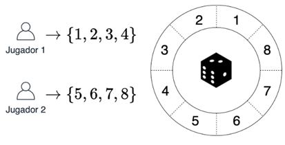

Imaginemos que hay un Jugador 1 y un Jugador 2 cada quien apuesta con sus respectivas casillas

de manera que tenemos 2 eventos excluyentes, si gana Jugador 1 no puede ganar Jugador 2. Veamos lo con colores para tener mayor comprensión. Dado que son eventos excluyentes, no hay intersecciones: empecemos preguntando ¿cuál es la probabilidad de que gane el jugador 1?

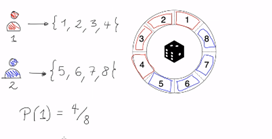

Contemplamos el espacio muestral y los casos de éxito. ¿Qué pasa si ahora establecemos una condición?

- Condición: ¿Cuál es la probabilidad de que sabiendo que cayo las combinaciones de B, gane el jugador 1? $P(1|B)$ Entonces como no hay una intersección, sabemos que el numero de eventos exitosos tiene que ser 0. Obviamente la condición B restringía el espacio muestral a 4, pero no hay una existencia de de suceso de evento, entonces la probabilidad es de 0.

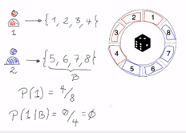

Aquí evidenciamos un ejercicios de eventos excluyentes.

¿Qué sucede si la situación cambia ligeramente?

Ahora el jugador vuelve a escoger sus casillas. Pero aquí es importante resaltar que el hecho de que los jugadores pueden escoger libremente sus casillas. Por lo que se cambia nuevamente el espacio muestral, y evidenciamos una intersección

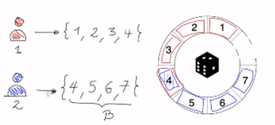

¿Que pasaría con la probabilidad de que gane el jugador 1 sabiendo que la pelota cayo con alguno de los elementos del jugador 2 (es decir B)?
Aquí de nuevo la condición restringe el espacio a solo 4 opciones y la intersección solo esta dada por un elemento. $$p(1|B)=\frac 1 4$$ Entonces este numero que esta queriendo decir. Esta queriendo decir que una vez que yo se que el jugador B ganó(jugador 2), la probabilidad de que también haya ganado el jugador 1 con ese conocimiento previo es de $\frac 1 4=25%$, cuando antes la probabilidad de que el jugador 1 ganara, así sin condición era del 50%. También quiere decir que la ocurrencia de que el jugador 2 haya ganado, reduce la probabilidad de que el jugador 1 haya ganado. Esto quiere decir que representan eventos negativamente correlacionados.

Podemos evidenciar otro par de ejercicios:

Suponemos que el jugador 2 toma la siguiente decisión {2,3,6,7} decimos ¿cuál es la probabilidad de que gane A, sabiendo que ganó B?

- Jugador 1 = A = {1,2,3,4}
- Jugador 2 = B = {2,3,6,7}
- $P(A|B) = \;?$ Decimos que ha ganado B, esto reduce el espacio a 4 y como hay intersección en 2 elementos {2,3}, entonces tenemos que es $P(A|B)=\frac 2 4$

### Correlación entre sucesos:

Decimos que dos sucesos están correlacionados si la ocurrencia de uno varía directamente sobre la probabilidad del otro, pueden ser:

Correlación positiva: la ocurrencia de un suceso incrementa la probabilidad de ocurrencia del otro Correlación negativa: la ocurrencia de un suceso disminuye la probabilidad de ocurrencia del otro

#### Nota:

Dos elementos excluyentes no son independientes, todo lo contrario tienen correlación negativa